# An Analysis of Coronavirus

# Exploratory Data Analysis

To begin, we first conduct some preliminary analysis of the dataset.

Table 1: Number of New Cases by Region

| Region | New Cases |
| --- | --- |
| Africa | 7632320 |
| Americas | 56483331 |
| Eastern Mediterranean | 18371085 |
| Europe | 132139679 |
| South-East Asia | 42746649 |
| Western Pacific | 16548925 |

Table 1 shows the number of new cases per region (as designated by the World Health Organization). However, while it would be easy to conclude that Europe experienced the most corona virus cases, this summary does not take into account the population residing in each region. Therefore, in order to have a more interpretable response variable, we shall standardize each region’s number of new cases by their respective populations.

To rescale the data, we will utilize the population for each country in a region (as drawn from [The World Data Bank](https://data.worldbank.org/indicator/SP.POP.TOTL)[^1]), and divide each country’s number of `New_cases` in a particular region, by the summed population of each country in the region. For the sake of interpretability, we will also multiply these newly-scaled data by a factor of $1,000$ as well.

Table 2: Number of (Scaled) New Cases by Region

| Region | New Cases (Scaled) |
| --- | --- |
| Africa | 7.645375 |
| Americas | 57.238161 |
| Eastern Mediterranean | 37.334534 |
| Europe | 170.540545 |
| South-East Asia | 21.414938 |
| Western Pacific | 8.975121 |

We will now proceed to analyze some of the more interesting variables in this dataset.

```
##                  WHO_region      New_cases      Cumulative_cases
##  Africa               :30548   Min.   :-32952   Min.   :       0
##  Americas             :23095   1st Qu.:     1   1st Qu.:    1649
##  Eastern Mediterranean:15875   Median :    76   Median :   23075
##  Europe               :36319   Mean   :  2179   Mean   :  477473
##  South-East Asia      : 6189   3rd Qu.:   782   3rd Qu.:  225837
##  Western Pacific      :13675   Max.   :500563   Max.   :42272014
##    New_deaths      Cumulative_deaths
##  Min.   : -43.00   Min.   :     0
##  1st Qu.:   0.00   1st Qu.:    24
##  Median :   1.00   Median :   363
##  Mean   :  31.23   Mean   :  9868
##  3rd Qu.:  10.00   3rd Qu.:  3932
##  Max.   :8786.00   Max.   :636017
```

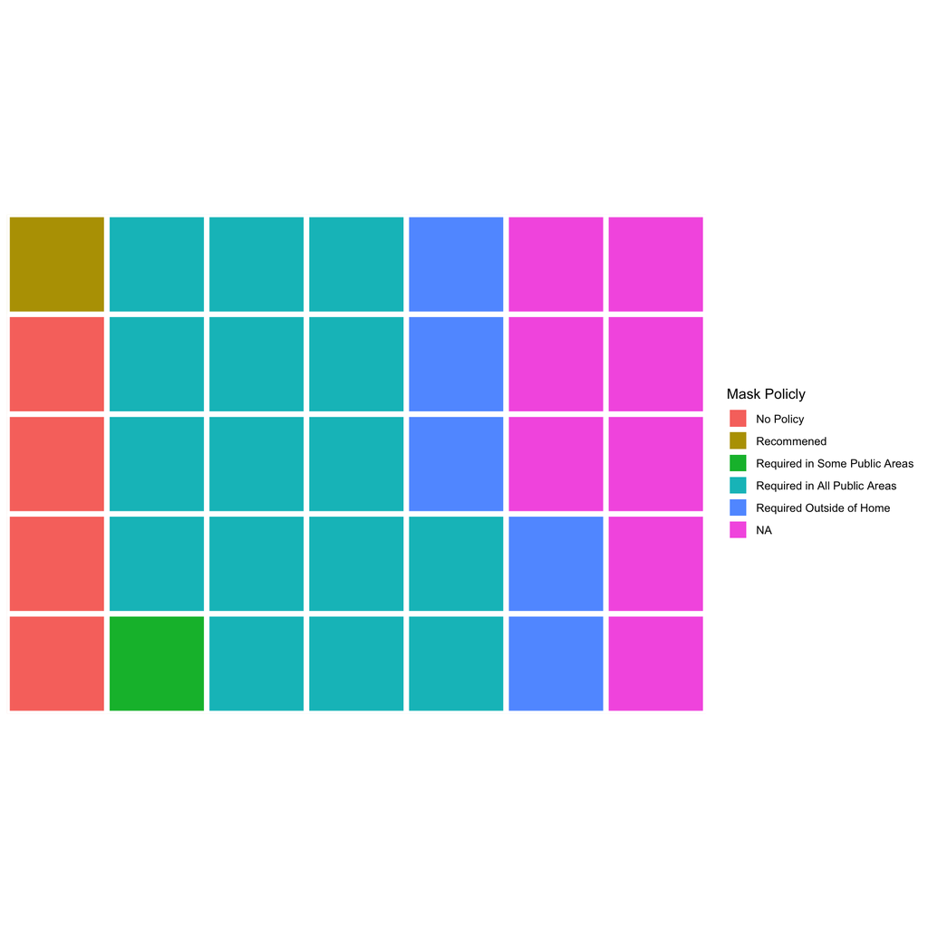

# ANCOVA Model

## Model

## Analysis

## Model Selection

## Diagnostics

# Model 2

## Diagnostics/Sensitivity Analysis

# Conclusion

# References

https://data.worldbank.org/indicator/SP.POP.TOTL

https://en.wikipedia.org/wiki/Demographics_of_Eritrea

[^1]: Most countries’ populations are based off of data from the year 2020. However, some countries such as Eritrea, haven’t conducted an official census as recently, and thus, estimates of the country’s population have been replaced with 2011 estimates.